# Analysis of Carbon Emissions

### Spring 2024 Data Science Project

###### By: Aditya Kalkar, Suhas Anumukonda, and Thomas Lazzarani

Member 1: Aditya Kalkar, Contribution: 100%

Member 2: Suhas Anumukonda, Contribution: 100%

Member 3: Thomas Lazzarani, Contribution: 100%

We, all team members, agree together that the above information is true, and we are confident about our contributions to this submitted project/final tutorial.

Aditya Kalkar - 5/7/24 Suhas Anumukonda - 5/7/24 Thomas Lazzarani - 5/7/24

Aditya Kalkar: Helped decide project idea and dataset. Worked on initial data preparation with the data frame. Wrote part of the functions of the data curation. Added matplotlib code for the box plots and the regression line. Furthermore, he was responsible for the code in part 3 to obtain the three R values. In part 4, Aditya did part of the primary analysis with the GBR model. Finally, he added to the conclusion and extra links at the end.

Suhas led the development of our machine learning model, particularly focusing on setting up the Gradient Boosting Regressor. He worked on coding tasks that transformed our dataset, making it ready for analysis. Suhas also handled part of the data visualization, creating plots that helped us understand the impact of lifestyle on carbon emissions. He was responsible for carrying out several statistical tests to support our findings and helped polish the final report to ensure clarity and accuracy.

Thomas concentrated on analyzing our data, writing scripts to explore correlations and create interactive plots that made our results easy to understand. He handled the bulk of the statistical analysis, using regression models to predict carbon emissions from various factors. Towards the end of the project, Thomas put together our findings, wrote the discussion and conclusion sections, and made sure our final report provided meaningful insights into how our results could affect policy and personal choices.

### Table of Contents:

1. Introduction
2. Data Curation
   - Preparation
   - Curation
3. Data Exploration
- Transportation
- Body type
- Clothing consumption
- Grocery Expendature
4. Primary Analysis
5. Conclusion

### Part 1: Introduction

Excessive carbon emissions are wreaking havoc on our ecosystem and planet, contributing significantly to the global climate crisis. The 2018 California wildfire and the 2023 Canada wildfires are some recent examples which clearly demonstrate the consequences of climate change, with vast areas of land scorched and hundreds of thousands forced to evacuate their homes. Furthermore, carbon emissions also significantly contribute to air pollution, leading to respiratory illnesses and premature deaths, especially in urban areas. In light of these significant challenges, understanding and mitigating individual carbon footprints becomes imperative. Although much of this responsibility falls on large corporations, there are still day to day changes people can make to do their part to help.  
Our project delves into this, using Data Science to analyze a large data set of people’s carbon footprints to understand how individual’s characteristics and choices contribute to their carbon emissions. By addressing questions such as how daily activities, consumption patterns, and lifestyle choices affect carbon emissions, this project aims to empower individuals to make informed decisions in reducing their environmental impact. Ultimately, this project aims not only to educate people on the environmental effects of their personal choices, but also serve as an example on how Data Science techniques, including ML evaluation can be used to form meaningful inferences and conclusions from data.

### Part 2a: Data Preparation

We started our process of data preparation and curation with data selection, for which we found a dataset which matched a number of personal characteristics and choices with estimated yearly carbon emissions, in kilograms (https://www.kaggle.com/datasets/dumanmesut/individual-carbon-footprint-calculation/data). These characteristics include transportation preferences, gender, showering frequency, time spent on technology, air travel frequency, and more. We chose this dataset not only due to its large size and number of features, but also because it could be used to train a regression model for estimating an individual's annual carbon footprint.

##### This step imports essential libraries for data processing, visualization, statistical analysis, machine learning model building, and saving the model.

```python
import pandas as pd
import matplotlib.pyplot as plt
import seaborn as sns
import ast
from scipy import stats
from sklearn.model_selection import train_test_split
from sklearn.metrics import mean_absolute_error, mean_squared_error, r2_score
from sklearn.ensemble import GradientBoostingRegressor
import joblib
```

```python
from google.colab import drive
drive.mount('/content/drive')

#https://www.kaggle.com/datasets/dumanmesut/individual-carbon-footprint-calculation
```

```python
from google.colab import drive
drive.mount('/content/drive')
```

#### Data loading and transformation

```python
df = pd.read_csv('/content/Carbon Emission.csv')
df['Recycling'] = df['Recycling'].apply(lambda x: ast.literal_eval(x))
df['Cooking_With'] = df['Cooking_With'].apply(lambda x: ast.literal_eval(x))
df.head(10)
```

|  | Body Type | Sex | Diet | How Often Shower | Heating Energy Source | Transport | Vehicle Type | Social Activity | Monthly Grocery Bill | Frequency of Traveling by Air | Vehicle Monthly Distance Km | Waste Bag Size | Waste Bag Weekly Count | How Long TV PC Daily Hour | How Many New Clothes Monthly | How Long Internet Daily Hour | Energy efficiency | Recycling | Cooking_With | CarbonEmission |
| --- | --- | --- | --- | --- | --- | --- | --- | --- | --- | --- | --- | --- | --- | --- | --- | --- | --- | --- | --- | --- |
| 0 | overweight | female | pescatarian | daily | coal | public | NaN | often | 230 | frequently | 210 | large | 4 | 7 | 26 | 1 | No | [Metal] | [Stove, Oven] | 2238 |
| 1 | obese | female | vegetarian | less frequently | natural gas | walk/bicycle | NaN | often | 114 | rarely | 9 | extra large | 3 | 9 | 38 | 5 | No | [Metal] | [Stove, Microwave] | 1892 |
| 2 | overweight | male | omnivore | more frequently | wood | private | petrol | never | 138 | never | 2472 | small | 1 | 14 | 47 | 6 | Sometimes | [Metal] | [Oven, Microwave] | 2595 |
| 3 | overweight | male | omnivore | twice a day | wood | walk/bicycle | NaN | sometimes | 157 | rarely | 74 | medium | 3 | 20 | 5 | 7 | Sometimes | [Paper, Plastic, Glass, Metal] | [Microwave, Grill, Airfryer] | 1074 |
| 4 | obese | female | vegetarian | daily | coal | private | diesel | often | 266 | very frequently | 8457 | large | 1 | 3 | 5 | 6 | Yes | [Paper] | [Oven] | 4743 |
| 5 | overweight | male | vegetarian | less frequently | wood | public | NaN | sometimes | 144 | frequently | 658 | large | 1 | 22 | 18 | 9 | Sometimes | [Paper, Glass, Metal] | [Stove, Oven, Microwave] | 1647 |
| 6 | underweight | female | vegan | less frequently | wood | private | hybrid | never | 56 | rarely | 5363 | medium | 4 | 9 | 11 | 19 | Sometimes | [] | [Grill, Airfryer] | 1832 |
| 7 | underweight | female | vegan | more frequently | coal | walk/bicycle | NaN | sometimes | 59 | very frequently | 54 | extra large | 3 | 5 | 39 | 15 | No | [Paper, Plastic, Glass] | [Stove, Microwave] | 2322 |
| 8 | overweight | male | omnivore | daily | wood | public | NaN | never | 200 | frequently | 1376 | medium | 3 | 3 | 31 | 15 | Yes | [Glass] | [Microwave, Grill, Airfryer] | 2494 |
| 9 | underweight | female | pescatarian | daily | wood | public | NaN | often | 135 | rarely | 440 | extra large | 1 | 8 | 23 | 18 | Sometimes | [Glass] | [Microwave, Grill, Airfryer] | 1178 |

### Part 2b: Data Curation

```python
from collections import defaultdict

def convertBodyWeight(x):
    d = defaultdict(lambda: 0)
    d["underweight"] = 1
    d["normal"] = 2
    d["overweight"] = 3
    d["obese"] = 4
    return d[x]

def convertGender(x):
    d = defaultdict(lambda: 0)
    d["male"] = 1
    d["female"] = 2
    return d[x]

def convertDiet(x):
    d = defaultdict(lambda: 0)
    d["vegan"] = 1
    d["vegetarian"] = 2
    d["pescatarian"] = 3
    d["omnivore"] = 4
    return d[x]

def convertEnergy(x):
    d = defaultdict(lambda: 0)
    d["natural gas"] = 1
    d["electricity"] = 2
    d["coal"] = 3
    d["wood"] = 4
    return d[x]

def convertShower(x):
    d = defaultdict(lambda:0)
    d["less frequently"] = 1
    d["daily"] = 2
    d["more frequently"] = 2
    d["twice a day"] = 4
    return d[x]

def convertTransport(x):
    d = defaultdict(lambda:0)
    d["walk/bicycle"] = 1
    d["public"] = 2
    d["private"] = 3
    return d[x]

def convertVehicleEnergy(x):
    d = defaultdict(lambda:0)
    d["electic"] = 1
    d["hybrid"] = 2
    d["petrol"] = 3
    d["lpg"] = 4
    d["diesel"] = 5
    return d[x]

def convertSocial(x):
    d = defaultdict(lambda:0)
    d["never"] = 1
    d["sometimes"] = 2
    d["often"] = 3
    return d[x]

def convertAir(x):
    d = defaultdict(lambda:0)
    d["never"] = 1
    d["rarely"] = 2
    d["frequently"] = 3
    d["very frequently"] = 4
    return d[x]

def convertTrash(x):
    d = defaultdict(lambda:0)
    d["small"] = 1
    d["medium"] = 2
    d["large"] = 3
    d["extra large"] = 4
    return d[x]

def convertEnergyEfficient(x):
    d = defaultdict(lambda:0)
    d["No"] = 1
    d["Sometimes"] = 2
    d["Yes"] = 3
    return d[x]

def convertRecycling(x):
    d = defaultdict(lambda:[0])
    d["Metal"] = 1
    d["Paper"] = 2
    d["Glass"] = 3
    d["Plastic"] = 4
    ans = []
    for item in x:
        ans.append(d[item])
    return len(ans)

def convertCooking(x):
    d = defaultdict(lambda:[0])
    d["Stove"] = 1
    d["Oven"] = 2
    d["Microwave"] = 3
    d["Grill"] = 4
    d["Airfryer"] = 5
    ans = []
    for item in x:
        ans.append(d[item])
    return len(ans)
```

### Part 3: Data Exploration

#### Monthy Vehicle Transport Effects on Carbon Emissions

This scatter plot explores the relationship between monthy vehicle distance and annual carbon emissions. The r_value of 0.594 shows that there is a moderate positive correlation between these features. This is expected, as transportation is a leading contributor to carbon emissions globally. We will break this down further in the following section, as we seperate emissions by transit categories.

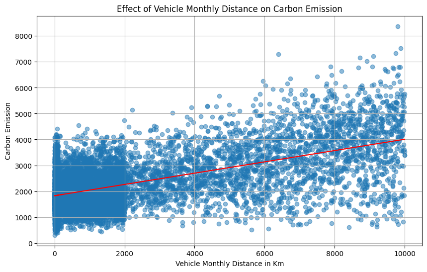

```
r-value is 0.5941712950028849
```

```python
vehicle_monthly_distance = df['Vehicle Monthly Distance Km']
carbon_emission = df['CarbonEmission']

plt.figure(figsize=(10, 6))
plt.scatter(vehicle_monthly_distance, carbon_emission, alpha=0.5)

slope, intercept, r_value, p_value, err = stats.linregress(vehicle_monthly_distance, carbon_emission)
regression_line = slope * vehicle_monthly_distance + intercept

# Plot regression line
plt.plot(vehicle_monthly_distance, regression_line, color='red', label='Linear Regression')


plt.title('Effect of Vehicle Monthly Distance on Carbon Emission')
plt.xlabel('Vehicle Monthly Distance in Km')
plt.ylabel('Carbon Emission')
plt.grid(True)
plt.show()

print("r-value is " + str(r_value))
```

The box plot suggests that carbon emissions vary significantly by transport type, with private transportation showing a higher median and greater spread of emissions, indicating it's generally less eco-friendly. Public transportation and walking/bicycling have lower medians and fewer outliers, suggesting they are more consistent low-emission options. The presence of outliers in all categories, especially private transport, could indicate extreme cases

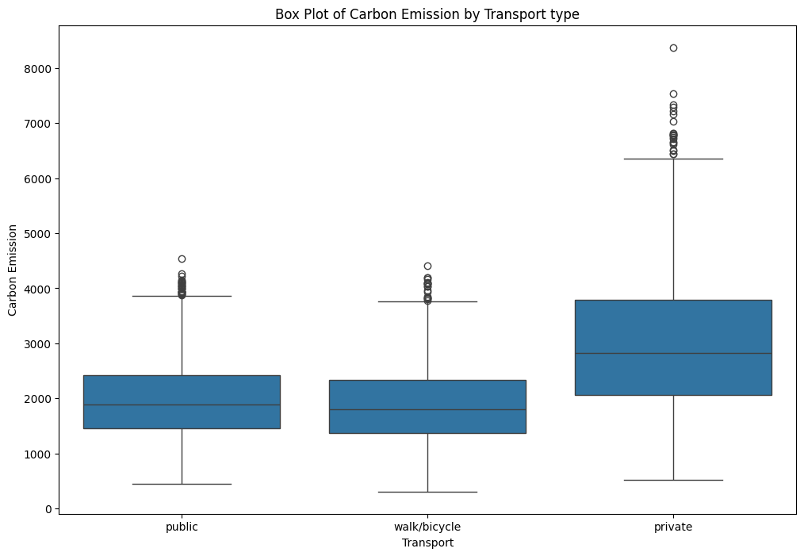

```python
plt.figure(figsize=(12, 8))
sns.boxplot(x='Transport', y='CarbonEmission', data=df)
plt.title('Box Plot of Carbon Emission by Transport type')
plt.xlabel('Transport')
plt.ylabel('Carbon Emission')
plt.show()
```

The previous two sections demonstrate how transportation as a whole contriutes to carbon emissions, and further how individual modes of transit differ from one another. Putting these together shows how regression lines differ across modes of transportation. The r-value for private transit shows a moderate positive correlation, whereas the r-value for public and walking/biking is near zero, showing how these modes of transportation have little impact on an individuals carbon emissions.

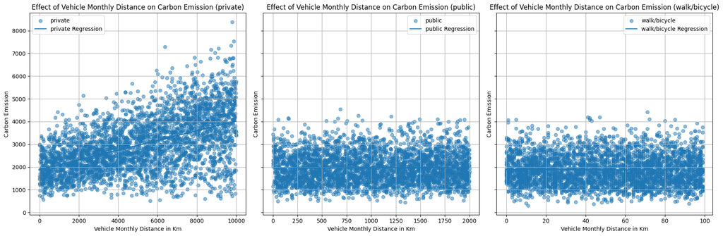

```
r-value for private 0.5109419437746021
r-value for public 0.007571902030833482
r-value for walk/bike -0.012644647228979353
```

```python
grouped = df.groupby('Transport')
fig, axes = plt.subplots(1, 3, figsize=(18, 6), sharey=True)
rvals = []

for ax, (transport, data) in zip(axes, grouped):
    vehicle_monthly_distance = data['Vehicle Monthly Distance Km']
    carbon_emission = data['CarbonEmission']

    slope, intercept,r_value, p_value, err = stats.linregress(vehicle_monthly_distance, carbon_emission)
    regression_line = slope * vehicle_monthly_distance + intercept

    ax.scatter(vehicle_monthly_distance, carbon_emission, alpha=0.5, label=transport)
    ax.plot(vehicle_monthly_distance, regression_line, label=f'{transport} Regression')

    ax.set_title(f'Effect of Vehicle Monthly Distance on Carbon Emission ({transport})')
    ax.set_xlabel('Vehicle Monthly Distance in Km')
    ax.set_ylabel('Carbon Emission')
    ax.legend()
    ax.grid(True)
    rvals.append(r_value)

plt.tight_layout()
plt.show()

print("r-value for private " + str(rvals[0]))
print("r-value for public " + str(rvals[1]))
print("r-value for walk/bike " + str(rvals[2]))
```

#### Mean Carbon Emissions Across Different Body Types

The graph below demonstrates that the greater a person's weight is, the larger their carbon emissions are. One possible explanation for this is because as a person grows in size, their required resources increase (food intake, waste, etc), thus leading to a larger carbon footprint

```
Body Type
underweight    2019.027165
normal         2140.509503
overweight     2358.919984
obese          2561.212000
Name: CarbonEmission, dtype: float64
```

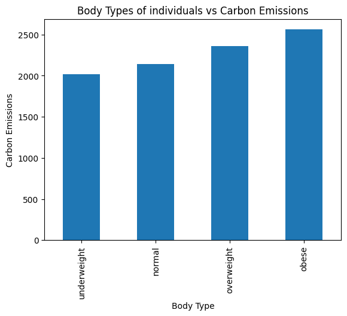

```python
groupweight = df.groupby('Body Type')
groupweightmean = groupweight['CarbonEmission'].mean().sort_values()
print(groupweightmean)

groupweightmean.plot(kind='bar',  title='Body Types of individuals vs Carbon Emissions', ylabel='Carbon Emissions')
plt.show()
```

#### Impact of Clothing Consumption on Carbon Emissions

The hypothesis test explores the relationship between the quantity of new clothes bought monthly and individual carbon emissions. By calculating the median number of clothes purchased and comparing carbon emissions for those who buy more versus fewer clothes than this median, a statistical test (t-test) is conducted to assess the significance of the difference. The results indicate a strong positive correlation, suggesting that higher clothing consumption may lead to greater carbon emissions. Additionally, the plot visualizing average carbon emissions for each clothing purchase level further illustrates this trend, providing a visual representation of how carbon output increases with the frequency of new clothing purchases. This analysis could have important implications for consumer behavior and environmental policies.

```
T-statistic: -17.072106629043116, P-value: 1.9511920672895078e-64
```

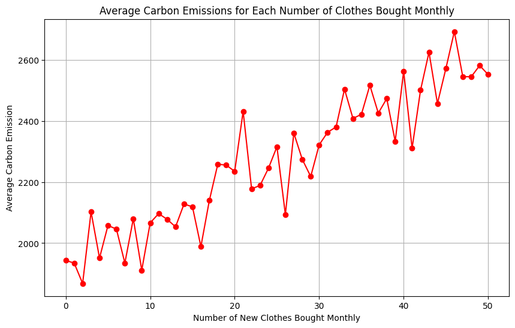

```python
median_clothes = df['How Many New Clothes Monthly'].median()


group_low = df[df['How Many New Clothes Monthly'] <= median_clothes]['CarbonEmission']
group_high = df[df['How Many New Clothes Monthly'] > median_clothes]['CarbonEmission']


t_stat, p_value = stats.ttest_ind(group_low, group_high)

print(f"T-statistic: {t_stat}, P-value: {p_value}")

avg_carbon_emissions = df.groupby('How Many New Clothes Monthly')['CarbonEmission'].mean().reset_index()
plt.figure(figsize=(10, 6))
plt.plot(avg_carbon_emissions['How Many New Clothes Monthly'], avg_carbon_emissions['CarbonEmission'], '-o', color='red')
plt.title('Average Carbon Emissions for Each Number of Clothes Bought Monthly')
plt.xlabel('Number of New Clothes Bought Monthly')
plt.ylabel('Average Carbon Emission')
plt.grid(True)
plt.show()
```

#### Correlation of monthy Grocery bill to Carbon Emissions

```
T-statistic: -17.072106629043116, P-value: 4.622311469968781e-13
```

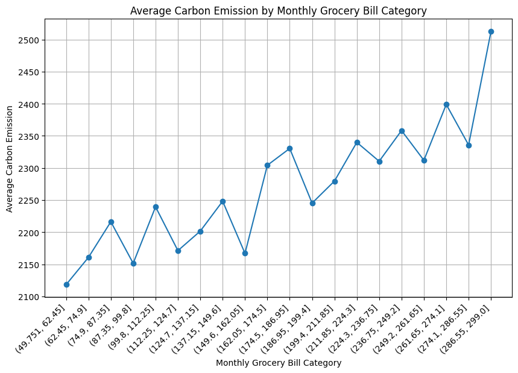

```python
min_value = df['Monthly Grocery Bill'].min()
max_value = df['Monthly Grocery Bill'].max()

lower_bills = df[df['Monthly Grocery Bill'] < df['Monthly Grocery Bill'].median()]
higher_bills = df[df['Monthly Grocery Bill'] >= df['Monthly Grocery Bill'].median()]

t_statistic, p_value = stats.ttest_ind(lower_bills['CarbonEmission'], higher_bills['CarbonEmission'])
print(f"T-statistic: {t_stat}, P-value: {p_value}")



num_bins = 20

bins = pd.cut(df['Monthly Grocery Bill'], bins=num_bins)

mean_emissions = df.groupby(bins)['CarbonEmission'].mean()

plt.figure(figsize=(10, 6))
plt.plot(mean_emissions.index.astype(str), mean_emissions.values, marker='o', linestyle='-')
plt.title('Average Carbon Emission by Monthly Grocery Bill Category')
plt.xlabel('Monthly Grocery Bill Category')
plt.ylabel('Average Carbon Emission')
plt.xticks(rotation=45, ha='right')
plt.grid(True)
plt.show()
```

### Part 4: Primary Analysis

```
Mean Absolute Error: 101.93029062068474
Mean Squared Error: 19136.754566606232
R-squared: 0.9823667264084711
```

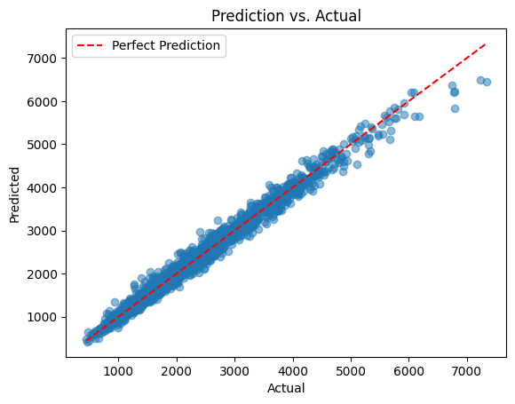

```python
import pandas as pd
import ast
from sklearn.model_selection import train_test_split
from sklearn.metrics import mean_absolute_error, mean_squared_error, r2_score
from sklearn.ensemble import GradientBoostingRegressor
import joblib
import matplotlib.pyplot as plt


df = pd.read_csv('Carbon Emission.csv')

df['Recycling'] = df['Recycling'].apply(lambda x: ast.literal_eval(x))
df['Cooking_With'] = df['Cooking_With'].apply(lambda x: ast.literal_eval(x))
df['Body Type'] = df['Body Type'].apply(lambda x: convertBodyWeight(x))
df['Sex'] = df['Sex'].apply(lambda x: convertGender(x))
df['Diet'] = df['Diet'].apply(lambda x: convertDiet(x))
df['How Often Shower'] = df['How Often Shower'].apply(lambda x: convertShower(x))
df['Heating Energy Source'] = df['Heating Energy Source'].apply(lambda x: convertEnergy(x))
df['Transport'] = df['Transport'].apply(lambda x: convertTransport(x))
df['Vehicle Type'] = df['Vehicle Type'].apply(lambda x: convertVehicleEnergy(x))
df['Social Activity'] = df['Social Activity'].apply(lambda x: convertSocial(x))
df['Frequency of Traveling by Air'] = df['Frequency of Traveling by Air'].apply(lambda x: convertAir(x))
df['Waste Bag Size'] = df['Waste Bag Size'].apply(lambda x: convertTrash(x))
df['Energy efficiency'] = df['Energy efficiency'].apply(lambda x: convertEnergyEfficient(x))
df['Recycling'] = df['Recycling'].apply(lambda x: convertRecycling(x))
df['Cooking_With'] = df['Cooking_With'].apply(lambda x: convertCooking(x))

x = df.drop(['CarbonEmission'], axis=1)
y = df['CarbonEmission']
xtrain, xtest, ytrain, ytest = train_test_split(x, y, test_size=0.2)

params = {
    'learning_rate': 0.17425361703048103,
    'max_depth': 3,
    'max_features': 'sqrt',
    'min_samples_leaf': 10,
    'min_samples_split': 20,
    'n_estimators': 500
}

gb_reg = GradientBoostingRegressor(**params, random_state=42)

gb_reg.fit(xtrain, ytrain)

pred = gb_reg.predict(xtest)

mse = mean_squared_error(ytest, pred)
r2 = r2_score(ytest, pred)
mae = mean_absolute_error(ytest, pred)

print("Mean Absolute Error:", mae)
print("Mean Squared Error:", mse)
print("R-squared:", r2)

joblib.dump(gb_reg, 'gradient_boosting_model.pkl')

# Plot prediction vs. actual
plt.scatter(ytest, pred, alpha=0.5)
plt.plot([min(ytest), max(ytest)], [min(ytest), max(ytest)], linestyle='--', color='red', label='Perfect Prediction')
plt.xlabel('Actual')
plt.ylabel('Predicted')
plt.title('Prediction vs. Actual')
plt.legend()
plt.show()
```

For the implementation of the Gradient Boosting Regression (GBR) algorithm, a number of factors influenced its selection over other machine learning methods for this regression problem. We chose GBR for its strength in handling diverse datasets, particularly ones where complex relationships exist between predictors and the target variable. This is especially good for our dataset, which has a large number of features. Unlike linear regression, which assumes the existence of linear relationships, GBR effecively captured the nonlinear relationships, making it good for modeling the patterns present in our data. GBR uses an ensemble approach, in which poor learners are fitted to correct the errors of previous models. This method is able to limit overfitting, ultimately enhancing its predictive accuracy.

GBR operates by iteratively fitting poor learners to the residuals of the previous model. Each subsequent iteration is trained to predict the residuals of the current ensemble, gradually refining the model's accuracy. Through this process, GBR is able to construct a strong model which can capture the complex, nonlinear, and diverse features of a dataset which are important for predicting the target, in our case annual carbon emissions.

## Part 5: Conclusion

Now that we have gone through the process of data collection, curation, exploratory analysis, hypothesis testing and visualization, we have come away with various takeaways from our data set. We can see that some decisions and characteristics of people have significant impact on their carbon footprint, such as their mode of transportation and clothing consumption among others. As stated in our introduction, we completed this project not only to demonstrate how applicable data science techniques can be used to draw meaningful conclusions from data with confidence, but additionally to empower individuals to take action to help reduce their carbon footprint. Using the ML model trained on our dataset, users can enter information about themselves to see an estimate of their annual carbon footprint, as well as explore which changes they can make to minimize their carbon footprint

[Carbon Footprint Predictor Demonstration](https://youtu.be/RgaZZur-ygk)

Although our investigation has been aimed towards informing individuals on actions they can take, an important public policy takeaway from this relates to transportation. As investigated in part three, the use of private transportation contributes significantly to one’s total carbon footprint, unlike the use of public transport which comparatively contributes far less. By investing in this mode of transit, governments could significantly reduce their citizen’s carbon footprint. Another takeaway for policymakers is to try to limit their populations' clothing consumption, another significant contributor to carbon footprint. This could be easily accomplished by encouraging thrifting and clothes drives, which not only would limit carbon emissions but also provide an economical option for purchasing clothing.

Extra links relating to Carbon Emissions:

1. https://www.epa.gov/ghgemissions/sources-greenhouse-gas-emissions#:~:text=The%20largest%20source%20of%20greenhouse,electricity%2C%20heat%2C%20and%20transportation.
2. https://ourworldindata.org/ghg-emissions-by-sector
3. https://www.rff.org/publications/explainers/federal-climate-policy-101/

Extra links relating to Gradient Boosting Regression and ML:

1. https://www.analyticsvidhya.com/blog/2021/09/gradient-boosting-algorithm-a-complete-guide-for-beginners/
2. https://www.simplilearn.com/gradient-boosting-algorithm-in-python-article
3. https://www.geeksforgeeks.org/applying-lambda-functions-to-pandas-dataframe/